# Lab 14 Solution

Danny Zweben

In this assignment, you will use the `ecls.rda` dataset and conduct two simple linear regressions where spring kindergarten reading scores are the outcome. One predictor is the family’s income, and the other predictor is the number of children less than 18 years old who live in the household.

## Problem 1 (0 pts)

```r
options(scipen = 100)
options(digits = 3)

library(haven)
library(ggplot2)
library(labelled)
library(psych)
library(stargazer)
```

## Problem 2 (0 pts)

```r
load("../ecls.rda")
ls()
```

```
## [1] "ecls"
```

## Problem 3 (1 pt)

```r
attributes(ecls)["variable.labels"]
```

```
## $variable.labels
##                                            childid
##                      "CHILD IDENTIFICATION NUMBER"
##                                               race
##                                     "Child's Race"
##                                           c2rtscor
##                          "Reading Score, Spring K"
##                                           c2mtscor
##                             "Math Score, Spring K"
##                                           c2gtscor
##                "General Knowledge Score, Spring K"
##                                            p1hmemp
##                       "Mother's Employment Status"
##                                           p2marsta
##                          "Parents' Marital Status"
##                                            wkpared
## "Education Level of Parent With Highest Education"
##                                           wkincome
##                                    "Family Income"
##                                            foodsec
##                              "Food Security Scale"
##                                           meddummy
##                           "Medical Care Indicator"
##                                             cogmat
##                        "Cognitive Materials Scale"
##                                             parinv
##                        "Parental Investment Scale"
##                                             warmth
##                                     "Warmth Scale"
##                                            cogstim
##                      "Cognitive Stimulation Scale"
##                                           p2less18
##                  "P2 NUMBER IN HOUSEHOLD AGED <18"
```

## Problem 4 (3 pt)

```r
ecls$z_read <- as.numeric(scale(ecls$c2rtscor))
ecls$z_income <- as.numeric(scale(ecls$wkincome))
ecls$z_kids <- as.numeric(scale(ecls$p2less18))
```

## Problem 5 (1 pt)

```r
ecls$income_k <- ecls$wkincome / 1000
```

## Problem 6 (1 pt)

```r
sub_ecls <- subset(
  ecls,
  !is.na(childid) & !is.na(c2rtscor) & !is.na(z_read) &
    !is.na(income_k) & !is.na(z_income) & !is.na(p2less18) & !is.na(z_kids),
  select = c(childid, c2rtscor, z_read, income_k, z_income, p2less18, z_kids)
)
head(sub_ecls)
```

|  | childid | c2rtscor | z_read | income_k | z_income | p2less18 | z_kids |
| --- | --- | --- | --- | --- | --- | --- | --- |
| 1 | 0001001C | 56.0 | 0.547 | 140 | 1.5596 | 2 | -0.424 |
| 2 | 0001002C | 69.6 | 1.918 | 120 | 1.2050 | 2 | -0.424 |
| 3 | 0001003C | 46.8 | -0.382 | 90 | 0.6731 | 3 | 0.414 |
| 4 | 0001004C | 49.1 | -0.156 | 60 | 0.1411 | 2 | -0.424 |
| 5 | 0001005C | 55.3 | 0.476 | 150 | 1.7369 | 2 | -0.424 |
| 6 | 0001006C | 39.6 | -1.113 | 50 | -0.0362 | 2 | -0.424 |

## Problem 7 (2 pts)

```r
nrow(ecls)
```

```
## [1] 21260
```

```r
nrow(sub_ecls)
```

```
## [1] 17488
```

```r
nrow(ecls) - nrow(sub_ecls)
```

```
## [1] 3772
```

## Problem 8 (1 pt)

```r
rm(ecls)
ls()
```

```
## [1] "sub_ecls"
```

## Problem 9 (6 pts)

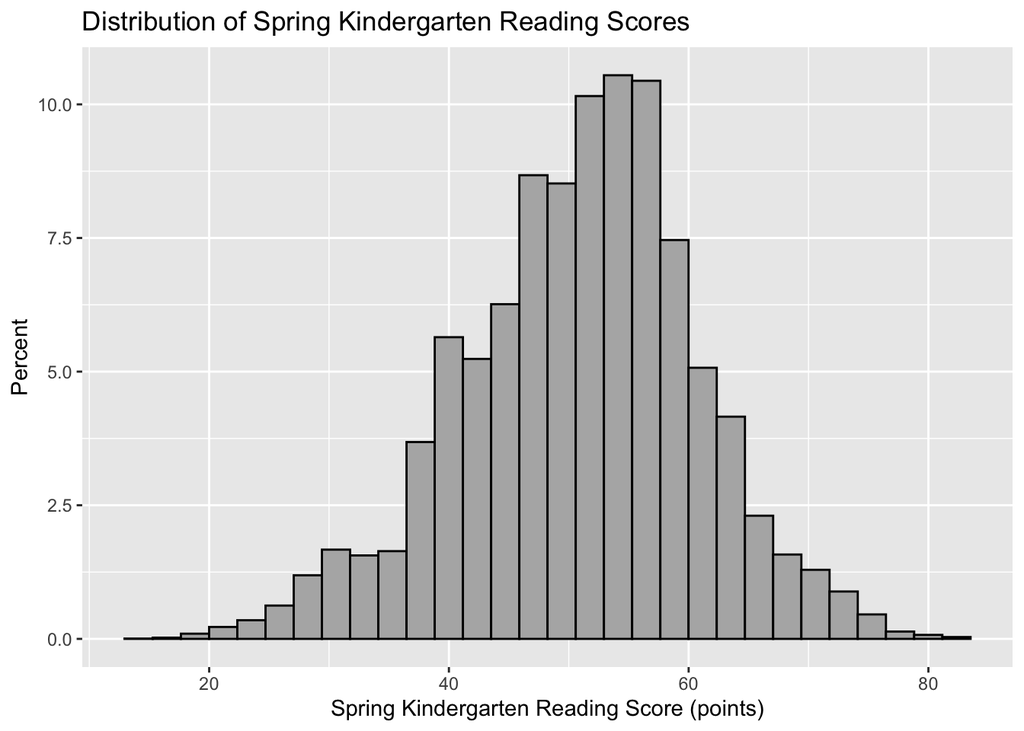

```r
ggplot(sub_ecls, aes(c2rtscor)) +
  geom_histogram(aes(y = (..count..) * 100 / sum(..count..)), fill = "grey70", color = "black") +
  ylab("Percent") +
  xlab("Spring Kindergarten Reading Score (points)") +
  ggtitle("Distribution of Spring Kindergarten Reading Scores")
```

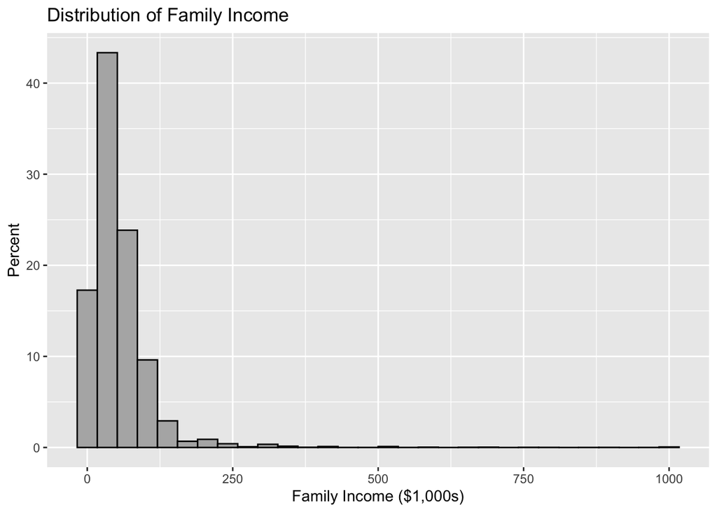

```r
ggplot(sub_ecls, aes(income_k)) +
  geom_histogram(aes(y = (..count..) * 100 / sum(..count..)), fill = "grey70", color = "black") +
  ylab("Percent") +
  xlab("Family Income ($1,000s)") +
  ggtitle("Distribution of Family Income")
```

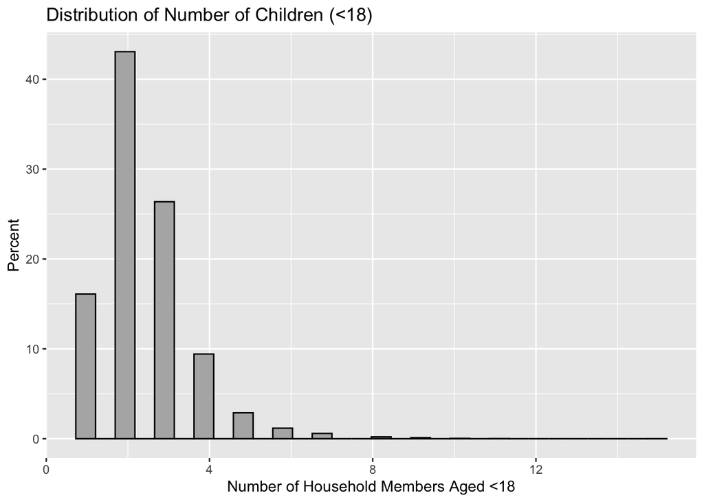

```r
ggplot(sub_ecls, aes(p2less18)) +
  geom_histogram(aes(y = (..count..) * 100 / sum(..count..)), fill = "grey70", color = "black") +
  ylab("Percent") +
  xlab("Number of Household Members Aged <18") +
  ggtitle("Distribution of Number of Children (<18)")
```

## Problem 10 (2 pts)

```r
m_income <- lm(c2rtscor ~ income_k, data = sub_ecls)
m_kids <- lm(c2rtscor ~ p2less18, data = sub_ecls)
summary(m_income)
```

```
##
## Call:
## lm(formula = c2rtscor ~ income_k, data = sub_ecls)
##
## Residuals:
##    Min     1Q Median     3Q    Max
## -47.76  -6.00   0.75   6.20  31.66
##
## Coefficients:
##             Estimate Std. Error t value            Pr(>|t|)
## (Intercept) 48.69921    0.09926   490.6 <0.0000000000000002 ***
## income_k     0.03991    0.00124    32.2 <0.0000000000000002 ***
## ---
## Signif. codes:  0 '***' 0.001 '**' 0.01 '*' 0.05 '.' 0.1 ' ' 1
##
## Residual standard error: 9.58 on 17486 degrees of freedom
## Multiple R-squared:  0.0561, Adjusted R-squared:  0.056
## F-statistic: 1.04e+03 on 1 and 17486 DF,  p-value: <0.0000000000000002
```

```r
summary(m_kids)
```

```
##
## Call:
## lm(formula = c2rtscor ~ p2less18, data = sub_ecls)
##
## Residuals:
##    Min     1Q Median     3Q    Max
## -36.60  -6.11   0.78   6.30  34.31
##
## Coefficients:
##             Estimate Std. Error t value            Pr(>|t|)
## (Intercept)  54.2223     0.1737   312.2 <0.0000000000000002 ***
## p2less18     -1.3447     0.0634   -21.2 <0.0000000000000002 ***
## ---
## Signif. codes:  0 '***' 0.001 '**' 0.01 '*' 0.05 '.' 0.1 ' ' 1
##
## Residual standard error: 9.73 on 17486 degrees of freedom
## Multiple R-squared:  0.0251, Adjusted R-squared:  0.025
## F-statistic:  450 on 1 and 17486 DF,  p-value: <0.0000000000000002
```

## Problem 11 (5 pts)

```r
stargazer(
  m_income, m_kids,
  type = "text",
  report = "vcs*",
  title = "Bivariate Regressions Predicting Spring Kindergarten Reading Scores",
  dep.var.caption = "Outcome",
  dep.var.labels = c("Reading (points)", "Reading (points)"),
  covariate.labels = c("Family Income ($1,000s)", "Number of Household Members Aged <18"),
  star.cutoffs = c(0.05, 0.01, 0.001),
  star.char = c("*", "**", "***"),
  notes = "Stars: * p<.05; ** p<.01; *** p<.001",
  notes.append = FALSE
)
```

```
##
## Bivariate Regressions Predicting Spring Kindergarten Reading Scores
## ==========================================================================
##                                                     Outcome
##                                      -------------------------------------
##                                                Reading (points)
##                                              (1)                (2)
## --------------------------------------------------------------------------
## Family Income (1,000s)                      0.040
##                                          (0.001)***
##
## Number of Household Members Aged <18                          -1.340
##                                                             (0.063)***
##
## Constant                                   48.700             54.200
##                                          (0.099)***         (0.174)***
##
## --------------------------------------------------------------------------
## Observations                               17,488             17,488
## R2                                          0.056              0.025
## Adjusted R2                                 0.056              0.025
## Residual Std. Error (df = 17486)            9.580              9.730
## F Statistic (df = 1; 17486)             1,039.000***        450.000***
## ==========================================================================
## Note:                                 Stars: * p<.05; ** p<.01; *** p<.001
```

## Problemn 12 (4 pts)

Model 1 (income): When family income is $0, the predicted spring kindergarten reading score is 48.699 points.

Model 2 (children): When there are 0 household members under 18, the predicted spring kindergarten reading score is 54.222 points.

## Problem 13 (4 pts)

Model 1 (income): For each additional $1,000 of family income, predicted reading score increases by 0.0399 points, `t(17486) = 32.23`, `p < .001`.

Model 2 (children): For each additional household member under 18, predicted reading score decreases by 1.3447 points, `t(17486) = -21.21`, `p < .001`.

## Problem 14 (4 pts)

Model 1 (income): `R^2 = .056`, so family income explains 5.61% of variation in spring kindergarten reading scores.

Model 2 (children): `R^2 = .025`, so number of household members under 18 explains 2.51% of variation in spring kindergarten reading scores.

## Problem 15 (2 pts)

```r
m_income_z <- lm(z_read ~ z_income, data = sub_ecls)
m_kids_z <- lm(z_read ~ z_kids, data = sub_ecls)
summary(m_income_z)
```

```
##
## Call:
## lm(formula = z_read ~ z_income, data = sub_ecls)
##
## Residuals:
##    Min     1Q Median     3Q    Max
## -4.821 -0.605  0.076  0.626  3.196
##
## Coefficients:
##             Estimate Std. Error t value            Pr(>|t|)
## (Intercept)  0.01585    0.00732    2.17                0.03 *
## z_income     0.22719    0.00705   32.23 <0.0000000000000002 ***
## ---
## Signif. codes:  0 '***' 0.001 '**' 0.01 '*' 0.05 '.' 0.1 ' ' 1
##
## Residual standard error: 0.967 on 17486 degrees of freedom
## Multiple R-squared:  0.0561, Adjusted R-squared:  0.056
## F-statistic: 1.04e+03 on 1 and 17486 DF,  p-value: <0.0000000000000002
```

```r
summary(m_kids_z)
```

```
##
## Call:
## lm(formula = z_read ~ z_kids, data = sub_ecls)
##
## Residuals:
##    Min     1Q Median     3Q    Max
## -3.694 -0.617  0.079  0.636  3.463
##
## Coefficients:
##             Estimate Std. Error t value            Pr(>|t|)
## (Intercept)  0.02352    0.00743    3.16              0.0016 **
## z_kids      -0.16198    0.00764  -21.21 <0.0000000000000002 ***
## ---
## Signif. codes:  0 '***' 0.001 '**' 0.01 '*' 0.05 '.' 0.1 ' ' 1
##
## Residual standard error: 0.982 on 17486 degrees of freedom
## Multiple R-squared:  0.0251, Adjusted R-squared:  0.025
## F-statistic:  450 on 1 and 17486 DF,  p-value: <0.0000000000000002
```

## Problem 16 (2 pt)

```r
stargazer(
  m_income_z, m_kids_z,
  type = "text",
  report = "vcs*",
  title = "Bivariate Regressions Predicting Reading Scores (SD Units)",
  dep.var.caption = "Outcome",
  dep.var.labels = c("Reading (SD)", "Reading (SD)"),
  covariate.labels = c("Family Income (SD)", "Number of Household Members Aged <18 (SD)"),
  star.cutoffs = c(0.05, 0.01, 0.001),
  star.char = c("*", "**", "***"),
  notes = "Stars: * p<.05; ** p<.01; *** p<.001",
  notes.append = FALSE
)
```

```
##
## Bivariate Regressions Predicting Reading Scores (SD Units)
## ===============================================================================
##                                                          Outcome
##                                           -------------------------------------
##                                                       Reading (SD)
##                                                   (1)                (2)
## -------------------------------------------------------------------------------
## Family Income (SD)                               0.227
##                                               (0.007)***
##
## Number of Household Members Aged <18 (SD)                          -0.162
##                                                                  (0.008)***
##
## Constant                                         0.016              0.024
##                                                (0.007)*           (0.007)**
##
## -------------------------------------------------------------------------------
## Observations                                    17,488             17,488
## R2                                               0.056              0.025
## Adjusted R2                                      0.056              0.025
## Residual Std. Error (df = 17486)                 0.967              0.982
## F Statistic (df = 1; 17486)                  1,039.000***        450.000***
## ===============================================================================
## Note:                                      Stars: * p<.05; ** p<.01; *** p<.001
```

## Problem 17 (2 pts)

In the z-standardized children model, when the number of household members under 18 is at the sample mean (`z_kids = 0`), predicted reading score is 0.0235 SD above the mean.

## Problem 18 (2 pts)

In the z-standardized children model, a 1 SD increase in number of household members under 18 predicts a 0.162 SD decrease in reading scores, `t(17486) = -21.21`, `p < .001`.

## Problem 19 (2 pts)

```r
summary(m_income)
```

```
##
## Call:
## lm(formula = c2rtscor ~ income_k, data = sub_ecls)
##
## Residuals:
##    Min     1Q Median     3Q    Max
## -47.76  -6.00   0.75   6.20  31.66
##
## Coefficients:
##             Estimate Std. Error t value            Pr(>|t|)
## (Intercept) 48.69921    0.09926   490.6 <0.0000000000000002 ***
## income_k     0.03991    0.00124    32.2 <0.0000000000000002 ***
## ---
## Signif. codes:  0 '***' 0.001 '**' 0.01 '*' 0.05 '.' 0.1 ' ' 1
##
## Residual standard error: 9.58 on 17486 degrees of freedom
## Multiple R-squared:  0.0561, Adjusted R-squared:  0.056
## F-statistic: 1.04e+03 on 1 and 17486 DF,  p-value: <0.0000000000000002
```

```r
summary(m_kids)
```

```
##
## Call:
## lm(formula = c2rtscor ~ p2less18, data = sub_ecls)
##
## Residuals:
##    Min     1Q Median     3Q    Max
## -36.60  -6.11   0.78   6.30  34.31
##
## Coefficients:
##             Estimate Std. Error t value            Pr(>|t|)
## (Intercept)  54.2223     0.1737   312.2 <0.0000000000000002 ***
## p2less18     -1.3447     0.0634   -21.2 <0.0000000000000002 ***
## ---
## Signif. codes:  0 '***' 0.001 '**' 0.01 '*' 0.05 '.' 0.1 ' ' 1
##
## Residual standard error: 9.73 on 17486 degrees of freedom
## Multiple R-squared:  0.0251, Adjusted R-squared:  0.025
## F-statistic:  450 on 1 and 17486 DF,  p-value: <0.0000000000000002
```

## Problem 20 (6 pts)

In separate bivariate regressions, spring kindergarten reading scores were positively associated with family income (in $1,000s), `B = 0.040`, `SE = 0.001`, `t(17486) = 32.23`, `p < .001`, `R^2 = .056`, and negatively associated with number of household members under 18, `B = -1.345`, `SE = 0.063`, `t(17486) = -21.21`, `p < .001`, `R^2 = .025`.

## Problem 21 (0 pts)

Upload your lab to Canvas. Double check to make sure the upload took.